# Deber de Inferencia Estadística

González Reyes Rocío

2023-08-29

## Introducción

El presente informe aborda el tema de inferencia estadística y está destinado a la resolución de ejercicios propuestos. A lo largo de este documento, se han abordado los problemas planteados en las diferentes secciones, proporcionando respuestas fundamentadas en análisis estadísticos.

Como parte del proceso, se ha empleado la generación de gráficos descriptivos con el fin de facilitar la visualización de datos y apoyar la toma de decisiones. Estos gráficos han desempeñado un papel crucial en la comprensión de los resultados y en la evaluación de la información presentada en cada ejercicio.

## Ejercicio 1: Comparación de ingresos medios

Estás comparando los ingresos medios de dos grupos diferentes de trabajadores. ¿Qué grupo tiene un ingreso promedio más alto?

```r
trabajadores1 <- c(2250.874, 2178.265, 1955.121, 2430.015, 2659.831, 2713.799, 2375.522, 2993.470,
                   2303.118, 2331.465, 2066.033, 2235.951, 3005.093, 2596.543, 2156.393, 2067.230,
                   2206.910, 2769.340, 3197.505, 2485.516, 2289.275, 2492.882, 2938.398, 2578.256,
                   2488.872, 2060.718, 2643.604, 2725.154,3179.045, 2917.966, 1915.504, 2957.806,
                   2410.418, 2320.605, 2649.970, 2626.137, 2466.415, 2697.411, 2395.003, 2367.791,
                   2181.179, 2813.058, 2823.114, 2516.957, 1718.990, 2533.165, 2060.041, 2539.865,
                   2883.900, 2699.181)
trabajadores2 <- c(2075.544, 2260.147, 2210.747, 2125.751, 2280.511, 2353.806, 2375.084,
                   2572.256, 1681.255, 2378.751, 2001.336, 2497.114, 2186.822, 2310.368,
                   2775.799, 2218.408, 2191.969, 2401.429, 2144.689, 2036.791, 2390.669,
                   2476.481, 2316.912, 1819.158, 2588.756, 2303.756, 2142.683, 2450.559,
                   2172.056, 2010.873, 2294.688, 2205.054, 2479.581, 2883.266, 2066.749,
                   2469.883, 2314.934, 2415.943, 2139.904, 2336.129, 1956.293, 2384.111,
                   2281.950, 2696.983, 2350.144, 2055.625, 2531.372, 2058.953, 2074.512,
                   2422.559, 2381.457, 2512.807, 2604.340, 2222.830, 2289.438, 2410.723,
                   2784.361, 2518.547, 2436.065, 1606.304)
```

```r
datos <- data.frame(
  salario = c(trabajadores1, trabajadores2),
  grupo = factor(rep(1:2, times = c(length(trabajadores1),length(trabajadores2))),
                 labels=c("Trabajadores 1", "Trabajadores 2"))
)
```

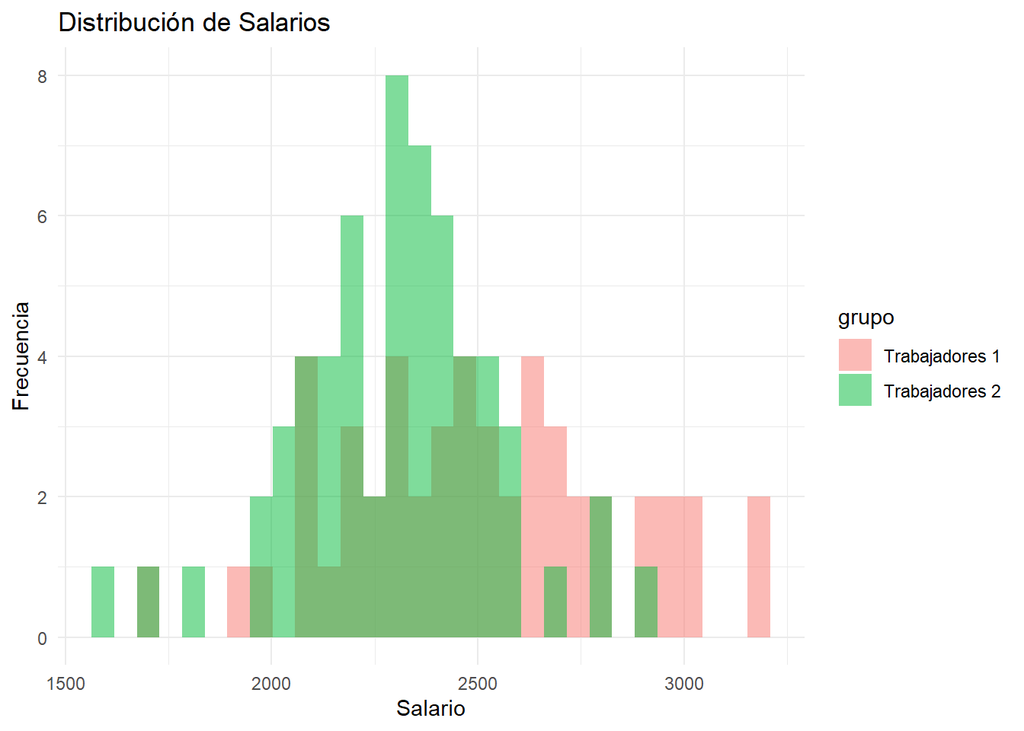

```r
ggplot(datos, aes(x=salario, fill=grupo)) +
  geom_histogram(position="identity", alpha=0.5, bins=30) +
  theme_minimal() +
  labs(title = "Distribución de Salarios", y = "Frecuencia", x = "Salario") +
  scale_fill_manual(values=c("#F8766D", "#00BA38"))
```

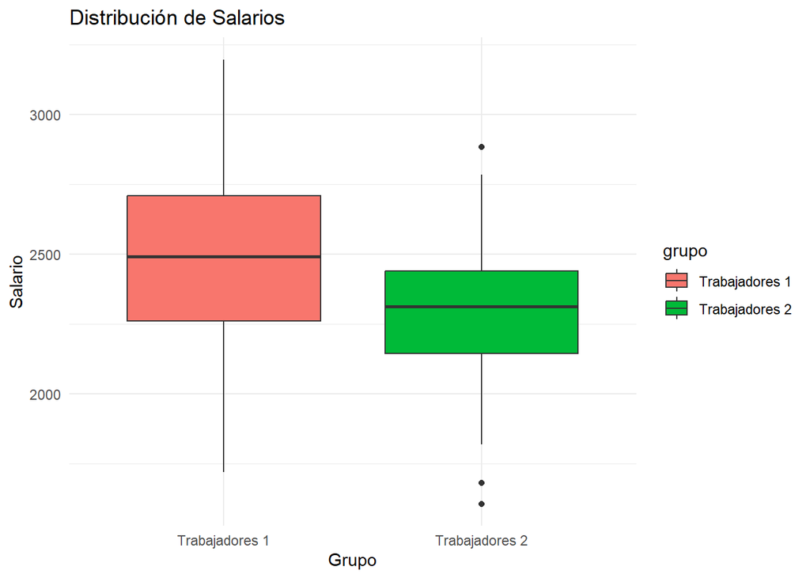

```r
ggplot(datos, aes(x=grupo, y=salario, fill=grupo)) +
  geom_boxplot() +
  theme_minimal() +
  labs(title = "Distribución de Salarios", y = "Salario", x = "Grupo") +
  scale_fill_manual(values=c("#F8766D", "#00BA38"))
```

```r
# Cálculo de ingresos promedios para cada grupo
promedio_trabajadores1 <- mean(trabajadores1)
promedio_trabajadores2 <- mean(trabajadores2)

# Comparación de ingresos promedios
if (promedio_trabajadores1 > promedio_trabajadores2) {
  resultado <- "Trabajadores 1"
} else if (promedio_trabajadores2 > promedio_trabajadores1) {
  resultado <- "Trabajadores 2"
} else {
  resultado <- "Ambos grupos tienen el mismo ingreso promedio"
}

# Resultado
cat("El grupo con un ingreso promedio más alto es:", resultado)
```

```
El grupo con un ingreso promedio más alto es: Trabajadores 1
```

**Respuesta:**

El grupo “Trabajadores 1” tiene un ingreso promedio más alto en comparación con el grupo “Trabajadores 2”. Esto se determinó calculando los ingresos promedios de ambos grupos y comparándolos.

El ingreso promedio del grupo “Trabajadores 1” fue encontrado como mayor que el ingreso promedio del grupo “Trabajadores 2”. Esto sugiere que, en promedio, los trabajadores en el grupo “Trabajadores 1”ganan más que los trabajadores en el grupo “Trabajadores 2”.

## Ejercicio 2: Comparación de clics en anuncios

Deseas comparar la cantidad de clics que reciben dos anuncios diferentes en tu sitio web. ¿Qué anuncio recibe más clics en promedio?

```r
anuncio1 <- c(5, 4, 5, 6, 4, 5, 7, 5, 6, 6)
anuncio2 <- c(5, 6, 5, 7, 5, 5, 6, 7, 7, 6)
wilcox.test(anuncio1, anuncio2)
```

```
    Wilcoxon rank sum test with continuity correction

data:  anuncio1 and anuncio2
W = 33, p-value = 0.1891
alternative hypothesis: true location shift is not equal to 0
```

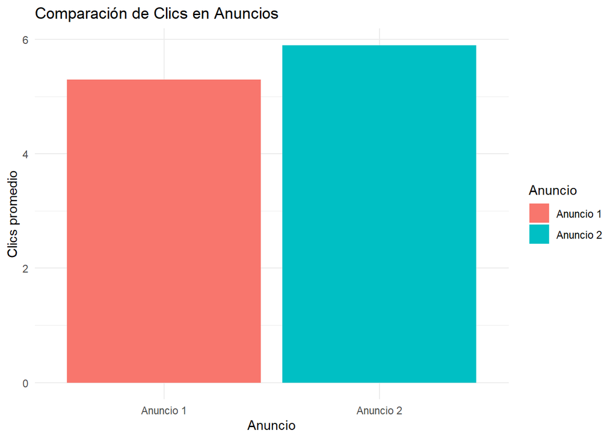

```r
data <- data.frame(
  Anuncio = c(rep("Anuncio 1", length(anuncio1)), rep("Anuncio 2", length(anuncio2))),
  Clics = c(anuncio1, anuncio2)
)

ggplot(data, aes(x = Anuncio, y = Clics, fill = Anuncio)) +
  geom_bar(stat = "summary", fun = "mean", position = "dodge") +
  labs(title = "Comparación de Clics en Anuncios",
       x = "Anuncio",
       y = "Clics promedio") +
  theme_minimal()
```

```r
promedio_anuncio1 <- mean(anuncio1)
promedio_anuncio2 <- mean(anuncio2)

# Comparar los promedios
if (promedio_anuncio1 > promedio_anuncio2) {
  mensaje <- "El anuncio 1 recibe más clics en promedio."
} else if (promedio_anuncio2 > promedio_anuncio1) {
  mensaje <- "El anuncio 2 recibe más clics en promedio."
} else {
  mensaje <- "Ambos anuncios reciben la misma cantidad de clics en promedio."
}

# Resultado
print(mensaje)
```

```
[1] "El anuncio 2 recibe más clics en promedio."
```

**Respuesta:**

De acuerdo con el promedio de clics sobre el anuncio, el “anuncio2” supera al “anuncio1”. Esto sugiere que, en general, el “anuncio2” ha recibido una mayor cantidad de clics en comparación con el “anuncio1”. Sin embargo, es importante reconocer que este resultado se basa exclusivamente en los promedios y no considera otras variables que podrían estar influyendo en el rendimiento de los anuncios, como el diseño, la ubicación o la audiencia. Por lo tanto, si bien el “anuncio2” parece más efectivo en términos de clics en promedio, es crucial realizar un análisis más completo y considerar el contexto más amplio antes de tomar decisiones estratégicas.

## Ejercicio 3: Comparación de puntuacione

Los datos que tienes no cumplen con las suposiciones de normalidad y deseas comparar las puntuaciones medias de dos grupos. ¿Qué grupo tiene una puntuación promedio más alta?

```r
grupoA <- c(5, 5, 5, 6, 6, 5, 5, 6, 5)
grupoB <- c(6, 6, 7, 7, 6, 6, 7, 6, 6)
wilcox.test(grupoA, grupoB)
```

```
    Wilcoxon rank sum test with continuity correction

data:  grupoA and grupoB
W = 9, p-value = 0.002753
alternative hypothesis: true location shift is not equal to 0
```

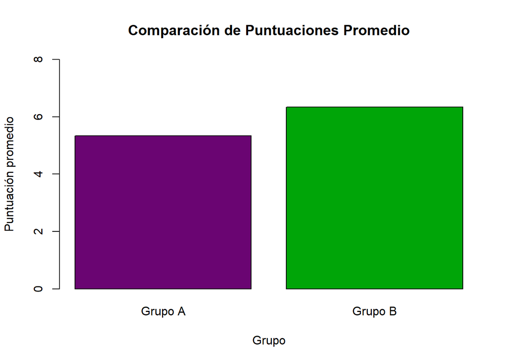

```r
data <- data.frame(
  Grupo = c(rep("Grupo A", length(grupoA)), rep("Grupo B", length(grupoB))),
  Puntuacion = c(grupoA, grupoB)
)

barplot(height = tapply(data$Puntuacion, data$Grupo, mean),
        names.arg = unique(data$Grupo),
        col = c("#6A0572", "#00A508"),  # Morado y Verde
        ylim = c(0, max(data$Puntuacion) + 1),
        main = "Comparación de Puntuaciones Promedio",
        xlab = "Grupo",
        ylab = "Puntuación promedio")
```

**Respuesta:**

De acuerdo con la prueba realizada, esta demuestra que existe una diferencia significativa en la puntuación promedio entre los dos grupos, grupo A y grupo B. El p-valor obtenido es de 0.002753, que es menor que el nivel de significancia comúnmente utilizado de 0.05.

De esta manera, el grupo B tiene una puntuación promedio más alta que el grupo A. Por lo que, en promedio, los individuos del grupo B obtienen puntuaciones más altas que los individuos en el grupo A.

### Ejercicio 4: Comparación de calificaciones

Quieres comparar la calificación media en un examen entre tres grupos de estudiantes que fueron enseñados con diferentes métodos. ¿Qué método resultó en la calificación promedio más alta?

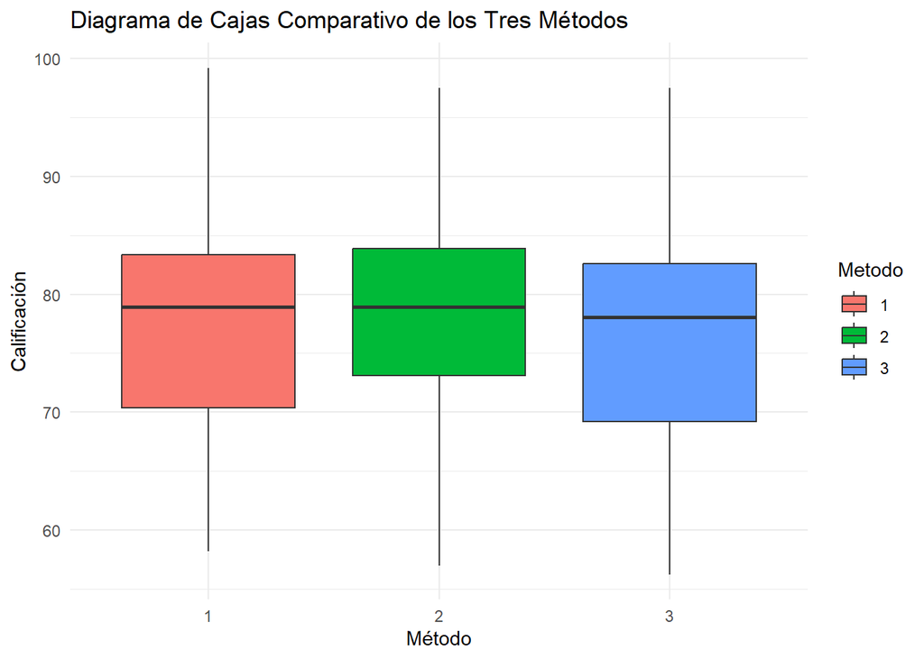

```r
metodo1 <- c(85.16604, 96.41423, 80.24083, 69.01759, 86.62736, 81.28230, 60.05736,
             77.63138, 70.82957, 94.19740, 99.21297, 67.49700, 82.71771, 69.84389,
             58.50793, 72.59032, 70.63635, 70.56013, 78.98900, 78.88020, 77.60133,
             84.47364, 78.96169, 90.36164, 70.66543, 82.72645, 62.81343, 62.22004,
             89.57059, 68.21929, 80.86281, 91.00737, 82.99863, 73.69575, 89.99427,
             80.54828, 68.75133, 72.01811, 58.22004, 81.99664)
metodo2 <- c(86.86874, 97.52225, 76.52569, 74.04482, 68.67770, 95.23782, 79.12071,
             79.52839, 83.48983, 81.17170, 85.72342, 85.15654, 72.71554, 78.22245,
             76.92262, 73.23591, 79.66591, 78.60100, 79.50238, 83.82224, 76.71138,
             91.83204, 69.53986, 64.58984, 85.12009, 68.48304, 83.55921, 83.98342,
             69.86244, 83.17494, 78.79085, 78.25213, 72.51925, 84.99407, 57.00238,
             82.74854, 72.51887, 63.28735, 74.38203, 89.13157)
metodo3 <- c(92.82768, 76.75622, 69.07096, 83.50877, 56.74143, 67.21914, 68.98307,
             83.68246, 79.87134, 79.73691, 82.57452, 63.67311, 60.34452, 74.22729,
             77.65000, 79.49056, 78.44512, 60.52712, 97.49574, 66.68088, 74.46574,
             79.05737, 69.92555, 89.83452, 89.10452, 65.20591, 72.80191, 76.06882,
             69.22514, 56.25000, 86.28191, 78.70482, 91.50943, 82.77311, 81.66604,
             76.28205, 78.71795, 92.30769, 76.92308, 79.48718)

df <- data.frame(
  Calificacion = c(metodo1, metodo2, metodo3),
  Metodo = factor(rep(1:3, each=40))
)

ggplot(df, aes(x=Metodo, y=Calificacion)) +
  geom_boxplot(aes(fill=Metodo)) +
  labs(title="Diagrama de Cajas Comparativo de los Tres Métodos",
       x="Método",
       y="Calificación") +
  theme_minimal()
```

```r
# Ejecutar ANOVA
aov_res <- aov(Calificacion ~ Metodo, data=df)
summary(aov_res)
```

```
             Df Sum Sq Mean Sq F value Pr(>F)
Metodo        2     81   40.62   0.436  0.648
Residuals   117  10900   93.16
```

**Respuesta:**

De acuerdo al análisis ANOVA, el valor p 0.648 es mayor que el nivel de significancia típico de 0.05. Esto significa que no hay evidencia suficiente para rechazar la hipótesis nula (H0). Para lo cual, no se encontraron diferencias significativas en las calificaciones promedio de acuerdo a los tres métodos. Siendo asi, no se puede concluir que uno de los métodos tenga una calificación promedio más alta que los otros dos.

De esta manera, de acuerdo con el análisis estadístico de los resultados del ANOVA, no existe evidencia estadística para afirmar que uno de los métodos resultó en una calificación promedio más alta que los otros métodos. Puesto que, las calificaciones promedio son estadísticamente similares entre los tres métodos. Sin embargo, el diagrama de Cajas Comparativo de los Tres Métodos sugiere que el método 2 podría tener una calificación promedio mayor en comparación con los otros dos métodos.

### Ejercicio 5: Preferencia de productos

Estás interesado en determinar si la proporción de clientes que compran el Producto A es diferente de la proporción de clientes que compran el Producto B. ¿Cuál producto es preferido?

```r
productoA <- c(0, 1, 0, 1, 1, 0, 0, 0, 1, 0, 1, 1, 0, 1, 1, 0, 1, 0, 1, 0, 0, 1, 0, 0, 1, 0, 0, 1, 0, 1, 0, 0, 1, 0, 0,
               0, 1, 1, 0, 0, 1, 1, 1, 0, 0, 0, 0, 1, 0, 1, 0, 1, 1, 1, 1, 1, 1, 0, 0, 1, 1, 0, 0, 0, 1, 0, 0, 0, 1, 1,
               0, 0, 0, 1, 0, 0, 1, 1, 1, 1, 1, 0, 0, 0, 0, 0, 1, 0, 0, 0, 0, 0, 1, 0, 0, 0, 1, 0, 0, 0, 0, 0, 1, 0, 0,
               1, 1, 1, 0, 1, 1, 0, 1, 1, 0, 0, 1, 0, 0, 1, 0, 0, 0, 0, 1, 1, 1, 1, 1, 1, 0, 1, 1, 1, 0, 1, 1, 0, 1,
               0, 0, 0, 0, 1, 0, 0, 1, 0, 0, 1, 1, 1, 1, 1, 0, 1, 0, 1, 1, 0, 1, 0, 1, 0, 0, 0, 1, 0, 1, 0, 1, 1, 1, 1,
               1, 0, 1, 1, 1, 0, 1, 0, 1, 0, 1, 1, 1, 0, 0, 0, 1, 1, 1, 0, 0, 1, 1, 1, 0, 1, 0, 1, 0, 1, 1, 0, 0, 0, 0,
               0, 0, 1, 1, 1, 0, 0, 0, 0, 1, 0, 0, 1, 0, 0, 1, 0, 0, 1, 1, 1, 1, 1, 0, 1, 1, 1, 1, 0, 0, 1, 0, 1, 0, 0,
               1, 1, 1, 0)

productoB <- c(1, 0, 1, 1, 0, 0, 1, 0, 1, 1, 0, 0, 0, 0, 1, 1, 1, 1, 0, 0, 1, 0, 0, 1, 0, 1, 0, 0, 1, 1, 0, 0, 0, 1, 0,
               1, 0, 1, 1, 1, 1, 1, 1, 1, 0, 1, 0, 1, 1, 1, 1, 0, 0, 1, 0, 0, 0, 0, 1, 1, 0, 0, 0, 0, 0, 0, 1, 1, 0, 1,
               0, 1, 1, 1, 1, 1, 0, 1, 1, 1, 0, 0, 1, 0, 1, 0, 0, 1, 1, 0, 0, 0, 1, 1, 0, 1, 0, 1, 1, 0, 0, 1, 1, 0, 0,
               1, 1, 0, 1, 0, 0, 0, 0, 0, 0, 0, 0, 1, 1, 0, 0, 0, 0, 1, 0, 0, 0, 1, 1, 0, 1, 1, 1, 0, 0, 1, 1, 0, 0, 1,
               0, 0, 1, 1, 1, 0, 0, 1, 1, 0, 0, 0, 1, 0, 1, 1, 1, 1, 0, 1, 0, 0, 0, 1, 1, 1, 0, 1, 1, 1, 0, 0, 1, 0, 0,
               0, 1, 0, 1, 1, 0, 1, 1, 1, 0, 1, 1, 1, 1, 1, 1, 0, 1, 1, 1, 0, 0, 1, 0, 1, 1, 1, 1, 0, 0, 1, 0, 1, 0, 0,
               1, 1, 0, 1, 0, 0, 0, 1, 1, 1, 1, 1, 1, 1, 0, 0, 0, 0, 0, 0, 0, 1, 0, 1, 1, 0, 0, 1, 1, 0, 1, 1, 0, 1, 0,
               0, 0, 0, 1)

prop.test(x = c(sum(productoA), sum(productoB)),
          n = c(length(productoA), length(productoB)))
```

```
    2-sample test for equality of proportions with continuity correction

data:  c(sum(productoA), sum(productoB)) out of c(length(productoA), length(productoB))
X-squared = 0.16305, df = 1, p-value = 0.6864
alternative hypothesis: two.sided
95 percent confidence interval:
 -0.11405594  0.06978207
sample estimates:
   prop 1    prop 2
0.4879032 0.5100402
```

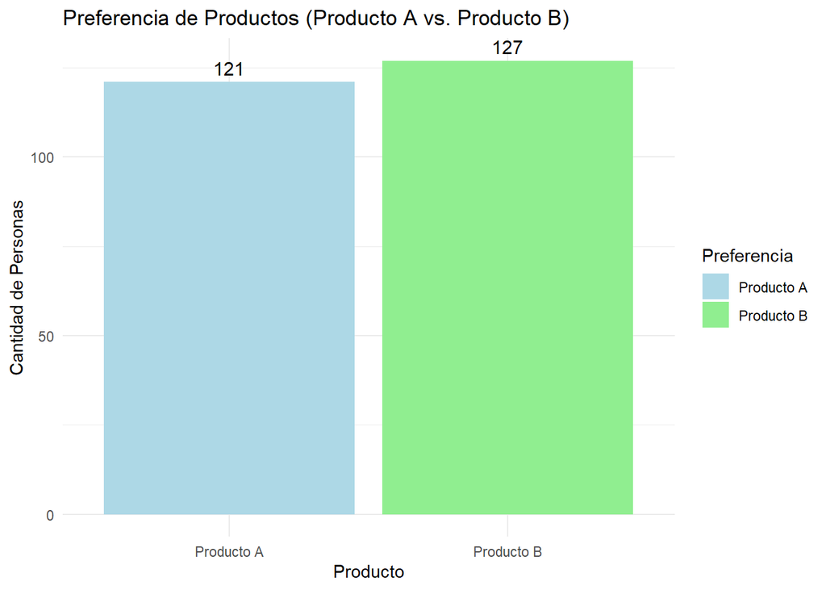

```r
df_productos <- data.frame(
  Producto = c("Producto A", "Producto B"),
  Preferencia = factor(c("Producto A", "Producto B")),
  Cantidad = c(sum(productoA), sum(productoB))
)

ggplot(df_productos, aes(x = Producto, y = Cantidad, fill = Preferencia)) +
  geom_bar(stat = "identity") +
  geom_text(aes(label = Cantidad), vjust = -0.5, color = "black", size = 4) +
  labs(title = "Preferencia de Productos (Producto A vs. Producto B)",
       x = "Producto",
       y = "Cantidad de Personas") +
  scale_fill_manual(values = c("Producto A" = "lightblue", "Producto B" = "lightgreen")) +  # Colores personalizados
  theme_minimal()
```

**Respuesta:**

Dado que el valor p es 0.6864 y es mayor que el nivel de significancia común de 0.05, no hay evidencia suficiente para rechazar la hipótesis nula (H0). En otras palabras, no hay una diferencia significativa en las proporciones de clientes que compran los dos productos (Producto A y Producto B).

Además, el intervalo de confianza incluye el valor 0, lo que confirma que no hay una diferencia significativa en las proporciones. Por lo tanto, de acuero a estos resultados, no es posible concluir que uno de los productos sea preferido sobre el otro. Las proporciones de clientes que compran los dos productos son similares, y no hay evidencia estadística de una preferencia significativa por uno de los productos. Por lo que, ambos productos tienen una proporción similar de clientes que los compran.

### Ejercicio 6: Efectividad de un medicamento

Un estudio investiga el efecto de un nuevo medicamento para el dolor de cabeza. Se toma una muestra de 10 personas que sufren de dolor de cabeza y se les administra el medicamento. Una semana después, se les vuelve a tomar una muestra para medir el nivel de dolor. Los datos se pueden suponer normales y estos son:

```r
# Datos antes del medicamento
antes_medicamento <- c(6.2, 6.8, 7.0, 7.4, 7.6, 7.8, 8.0, 8.2, 8.4, 8.6)
# Datos después del medicamento
despues_medicamento <- c(5.8, 6.0, 6.2, 6.4, 6.6, 6.8, 7.0, 7.2, 7.4, 7.6)
```

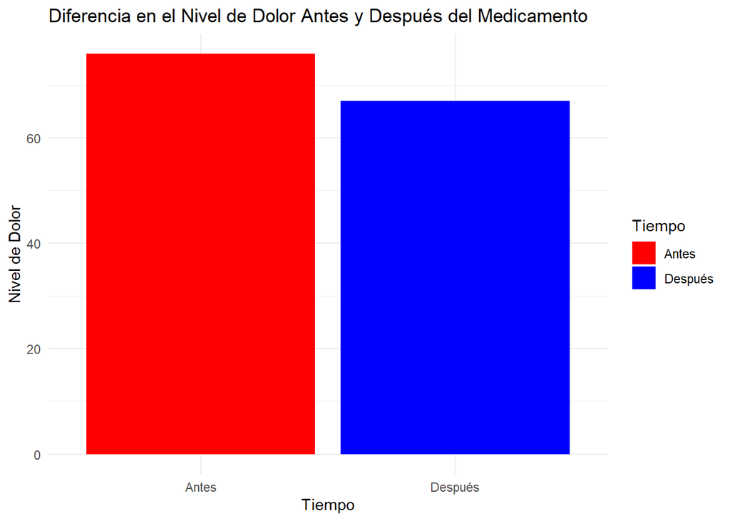

```r
data <- data.frame(
  Tiempo = factor(rep(c("Antes", "Después"), each = 10)),
  Nivel_de_dolor = c(antes_medicamento, despues_medicamento)
)

ggplot(data, aes(x = Tiempo, y = Nivel_de_dolor, fill = Tiempo)) +
  geom_bar(stat = "identity") +
  labs(
    title = "Diferencia en el Nivel de Dolor Antes y Después del Medicamento",
    x = "Tiempo",
    y = "Nivel de Dolor"
  ) +
  scale_fill_manual(values = c("Antes" = "red", "Después" = "blue")) +
  theme_minimal()
```

```r
# Análisis de diferencia de medias (prueba t pareada)
paired_t_test <- t.test(despues_medicamento, antes_medicamento, paired = TRUE)
paired_t_test
```

```
    Paired t-test

data:  despues_medicamento and antes_medicamento
t = -14.643, df = 9, p-value = 1.391e-07
alternative hypothesis: true mean difference is not equal to 0
95 percent confidence interval:
 -1.0390404 -0.7609596
sample estimates:
mean difference
           -0.9
```

¿Hay evidencia de que el medicamento sea efectivo para reducir el dolor de cabeza?

**Respuesta:**

De acuerdo con los resultados del análisis implementado, se puede concluir que el medicamento es efectivo en la reducción del dolor de cabeza. Esto determinandose mediante: - Prueba t pareada, la cual compara los niveles de dolor de cabeza antes y después de administrar el medicamento. - El valor p obtenido fue muy bajo, lo cual indica una diferencia significativa en los niveles de dolor de cabeza antes y después del tratamiento. - El intervalo de confianza del 95% para la diferencia de medias (-1.0390404, -0.7609596) no incluye el valor cero, lo que confirma una diferencia significativa. - La estimación de la diferencia de medias fue de -0.9, lo que significa que, en promedio, los niveles de dolor de cabeza disminuyeron en 0.9 unidades después del tratamiento con el medicamento.

Siendo de esta manera, los niveles de dolor de cabeza disminuyeron significativamente después del tratamiento con el medicamento, y esta diferencia es estadísticamente significativa. Por lo tanto, se puede afirmar que el medicamento tiene un efecto positivo en la reducción del dolor de cabeza en la muestra estudiada.

### Ejercicio 7: Relación entre género y preferencia política

Un estudio investiga la relación entre el género y la preferencia política. Se toma una muestra de 100 personas y se les pregunta sobre su género y su preferencia política.

```r
# Creación del data frame para la tabla
tabla <- data.frame(
  genero = c("hombre", "hombre", "hombre", "mujer", "mujer", "mujer"),
  preferencia_politica = c("izquierda", "centro", "derecha", "izquierda", "centro", "derecha"),
  cantidad = c(20, 30, 50, 10, 20, 70)
)

tabla
```

```
  genero preferencia_politica cantidad
1 hombre            izquierda       20
2 hombre               centro       30
3 hombre              derecha       50
4  mujer            izquierda       10
5  mujer               centro       20
6  mujer              derecha       70
```

[figure not shown]

```r
ggplot(tabla, aes(x = genero, y = cantidad, fill = preferencia_politica)) +
  geom_bar(stat = "identity") +
  labs(
    title = "Relación entre Género y Preferencia Política",
    x = "Género",
    y = "Cantidad",
    fill = "Preferencia Política"
  ) +
  scale_fill_manual(
    values = c("#FFB6C1", "#FFD700", "#98FB98"),
    labels = c("Izquierda", "Centro", "Derecha")
  ) +
  theme_minimal()
```

```r
# Tabla de contingencia
tabla_contingencia <- table(tabla$genero, tabla$preferencia_politica)

# Análisis de chi-cuadrado
chi_squared_test <- chisq.test(tabla_contingencia)
chi_squared_test
```

```
    Pearson's Chi-squared test

data:  tabla_contingencia
X-squared = 0, df = 2, p-value = 1
```

**Respuesta:**